# Multilevel

20 January 2017

In order to take into account the complex structure of repeated measurements from different assays where different treatments are applied on the same subjects, a multilevel multivariate approach was developed to highlight the treatment effects within subject separately from the biological variation between subject (collaboration with A/Prof. B. Liquet).

Two different frameworks are proposed:

**1.** A discriminant analysis (*method = ‘splsda’*) enables the selection of features separating the different treatments (indicated by the vector or the matrix ‘cond‘).

**2.** A integrative analysis (*method = ‘spls’*) enables the interaction of two matched data sets and the selection of subset of correlated variables (positively or negatively) across the samples. The approach is unsupervised: no prior knowledge about the samples groups is included.

The multilevel function first decomposes the variance in the data sets X (and Y) and applies either sPLS-DA or sPLS on the within-subject deviation. One or two-factor analyses are available for sPLS-DA.

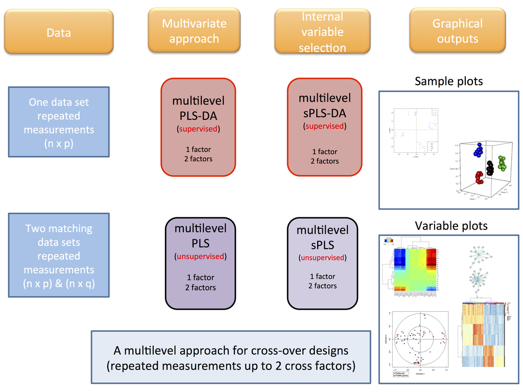

Multilevel Framework

# Usage in mixOmics

```r
library(mixOmics)
data(vac18)
X <- vac18$genes
Y <- vac18$stimulation

# sample indicates the repeated measurements
# setup the design matrix by indicating the repeated measurements
design <- data.frame(sample = vac18$sample)

# multilevel sPLS-DA model
vac18.splsda.multilevel <- splsda(X,
                                  Y = vac18$stimulation,
                                  multilevel = design,
                                  ncomp = 3,
                                  keepX = c(30, 137, 123))
```

## Variable Selection

A tuning function **tune.multilevel()** is proposed to tune the number of variables to select:

**1.** Either using leave-one-out cross validation for sPLS-DA one factor analysis.

```r
tune.loo.vac18 <- tune.multilevel(X, Y, multilevel = vac18$sample,
                               ncomp=2,
                               test.keepX=c(5, 10, 15),
                               already.tested.X = c(50),
                               method = 'splsda',
                               dist = 'mahalanobis.dist',
                               validation = 'loo')
```

**2.** Maximising the correlation between the latent variables for sPLS-DA two factors analysis or sPLS on the whole data set (applies when there are too many conditions and not enough samples).

```r
# Two factor analysis with sPLS-DA
data("liver.toxicity")

dose <- as.factor(liver.toxicity$treatment$Dose.Group)
time <- as.factor(liver.toxicity$treatment$Time.Group)

# note: we made up those data, pretending they are repeated measurements
repeat.indiv <- c(1, 2, 1, 2, 1, 2, 1, 2, 3, 3, 4, 3, 4, 3, 4, 4, 5, 6, 5, 5,
                    6, 5, 6, 7, 7, 8, 6, 7, 8, 7, 8, 8, 9, 10, 9, 10, 11, 9, 9,
                    10, 11, 12, 12, 10, 11, 12, 11, 12, 13, 14, 13, 14, 13, 14,
                    13, 14, 15, 16, 15, 16, 15, 16, 15, 16)

summary(as.factor(repeat.indiv)) # 16 rats, 4 measurements each

design <- data.frame(sample = repeat.indiv)

liver.tune = tune.multilevel(liver.toxicity$gene,
                             Y = data.frame(dose, time),
                             multilevel = design,
                             ncomp=2,
                             test.keepX=c(5, 10, 15),
                             already.tested.X = c(50),
                             method = 'splsda',
                             dist = 'mahalanobis.dist')
```

See [Case Study: Multilevel vac18](http://mixomics.org/case-studies/multilevelvac18/) for more tuning details and plotting options.

# References

[Liquet, B., Lê Cao, K.A., Hocini, H. and Thiébaut, R., 2012. A novel approach for biomarker selection and the integration of repeated measures experiments from two assays. BMC bioinformatics, 13(1), p.325.](https://bmcbioinformatics.biomedcentral.com/articles/10.1186/1471-2105-13-325)